# LOOP Notes and Analyses

## Creating HP specific Dataframe : midlife_HP_df

Total N - 43

```r
# Let's create a clean df to work with here and include only the columns we want

midlife_HP_df <-
  midlife_raw_df %>%  dplyr::select(
    "subject_id",
    "sex",
    "age_spatial_years",
    "repo_status",
    "loop_pe_rad3_m",
    "loop_pe_avg_m",
    "loop_de_rad3_degree",
    "loop_de_avg_degree",
    "loop_ae_rad3_degree",
    "loop_ae_avg_degree",
    "t1_vbm_tiv",
    "t1_vbm_gmv",
    "t1_vbm_wmv",
    "t1_vbm_csf",
    "t1_vol_left_hipp_aal_2d_d1_r",
    "t1_vol_right_hipp_aal_2d_d1_r",
    "t1_vol_left_hipp_aal_3d_d1_s",
    "t1_vol_right_hipp_aal_3d_d1_s",
    "t2hipp_vol_avg_ca1",
    "t2hipp_vol_avg_ca23",
    "t2hipp_vol_avg_dg",
    "t2hipp_vol_avg_erc",
    "t2hipp_vol_avg_phc",
    "t2hipp_vol_avg_prc",
    "t2hipp_vol_avg_sub",
    "t2hipp_vol_left_ca1" ,
    "t2hipp_vol_left_ca23",
    "t2hipp_vol_left_dg",
    "t2hipp_vol_left_erc",
    "t2hipp_vol_left_phc",
    "t2hipp_vol_left_prc",
    "t2hipp_vol_left_sub"  ,
    "t2hipp_vol_right_ca1",
    "t2hipp_vol_right_ca23",
    "t2hipp_vol_right_dg",
    "t2hipp_vol_right_prc",
    "t2hipp_vol_right_sub",
    "Left-Hippocampus",
    "Right-Hippocampus",
    "eTIV"
  ) %>% mutate(avg_t1_hipp = (.$`Left-Hippocampus` + .$`Right-Hippocampus`) /
                 2) %>% filter(!is.na(eTIV)) # Need to make sure we remove subj without scan # N=43

midlife_HP_female_df <- midlife_HP_df %>% filter(sex=="Female")

midlife_HP_male_df <- midlife_HP_df %>%  filter(sex== "Male")
```

## Checking normality

- Degrees traveled for all midlife is not normally distributed (p=0.04) and degrees traveled for men only ( p = 0.0001979)
- Position error was normally distributed for all groups
- Angular error rad3 was normally distributed for alll groups
- Angular error average for midlife was not normally distributed (p = 0.0007472) and it was not normally distributed for women only ( p-value = 0.004246)

```r
knitr::kable(normality_midlife_HP) %>% kable_styling(bootstrap_options =  c("striped", "hover", "condensed")) %>% scroll_box(width = "800px", height = "300px")
```

[output not shown]

## Behavior summarized

```r
loop_summarystats <- midlife_HP_df  %>%
  group_by(sex) %>%
  summarize(n_subject = n(),
            age_mean = mean(age_spatial_years),
            age_Sd = sd(age_spatial_years),
            AE_rad3 = mean(loop_ae_rad3_degree,na.rm=TRUE),
            AE_avg = mean(loop_ae_avg_degree ,na.rm=TRUE),
            PE_rad3 = mean(loop_pe_rad3_m,na.rm=TRUE),
            PE_avg = mean(loop_pe_avg_m,na.rm=TRUE),
            DT_rad3 = mean(loop_de_rad3_degree,na.rm=TRUE),
            DT_avg = mean(loop_de_avg_degree,na.rm=TRUE)) %>% as.data.frame()
```

```r
knitr::kable(loop_summarystats) %>% kable_styling(bootstrap_options =  c("striped", "hover", "condensed")) %>% scroll_box(width = "800px", height = "200")
```

| sex | n_subject | age_mean | age_Sd | AE_rad3 | AE_avg | PE_rad3 | PE_avg | DT_rad3 | DT_avg |
| --- | --- | --- | --- | --- | --- | --- | --- | --- | --- |
| Female | 26 | 50.23077 | 3.701974 | 69.8513 | 58.99396 | 3.130604 | 1.846265 | 393.4124 | 375.6190 |
| Male | 17 | 50.35294 | 3.920159 | 64.9243 | 51.29080 | 2.871218 | 1.632895 | 328.1449 | 338.1785 |

## T1 Correlations

## Shuyings code

Shuying originally did an adjustment. so that’s waht we’re doing below. First we need to correct the T1 hippocampal volumes for TIV. T1 volumes and TIV are coming from freesurfers recon all.

```r
#v contains adjusted hip
# 1 Create function for apply to variables
dividebyTIV <- function(x, na.rm = FALSE) (x/midlife_HP_df$eTIV)

# 2 Let's correct by mutating the columns using the TIV from freesurfer

midlife_HP_df_adj <- midlife_HP_df %>% mutate_at(vars(avg_t1_hipp, `Left-Hippocampus`, `Right-Hippocampus`),
            dividebyTIV) %>%

  # multiplying to get proportions
   mutate(avg_t1_hipp = avg_t1_hipp*1000,
         `Left-Hippocampus` = `Left-Hippocampus`*1000,
         `Right-Hippocampus` = `Right-Hippocampus`*1000)
```

Now that things have been adjusted I need to do correlations ### Total HP

** position Error **

- Position error avg is not significantly associated with t1 total hippocampus R=0.22, p=0.15

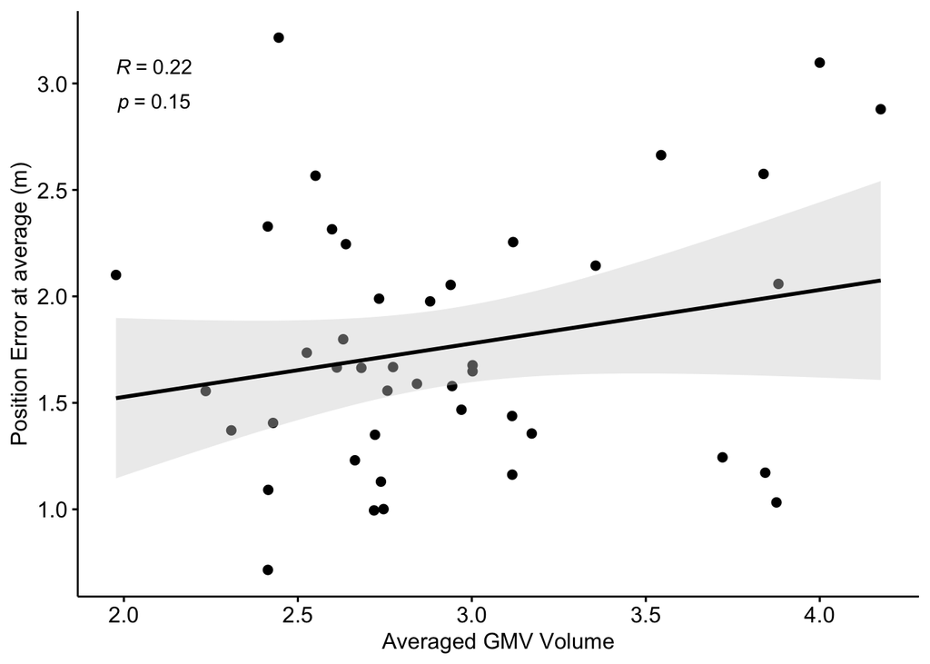

```r
# Use hp data frame adjusted
ggscatter(midlife_HP_df_adj, x = "avg_t1_hipp", y = "loop_pe_avg_m",
          add = "reg.line",
          add.params = list(color = "black", fill = "lightgray"), # Customize reg. line
          cor.coef = TRUE, # Add correlation coefficient. see ?stat_cor
          conf.int = TRUE,
          cor.method = "pearson",
          cor.coeff.args = list(label.sep = "\n"),
          xlab = "Averaged GMV Volume", ylab = "Position Error at average (m)", ) +
    theme(legend.position = "top", legend.title=element_blank())
```

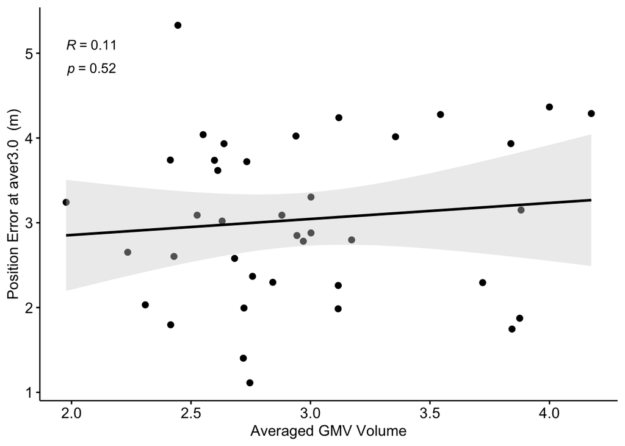

```r
# Use hp data frame adjusted
ggscatter(midlife_HP_df_adj, x = "avg_t1_hipp", y = "loop_pe_rad3_m",
          add = "reg.line",
          add.params = list(color = "black", fill = "lightgray"), # Customize reg. line
          cor.coef = TRUE, # Add correlation coefficient. see ?stat_cor
          conf.int = TRUE,
          cor.method = "pearson",
          cor.coeff.args = list(label.sep = "\n"),
          xlab = "Averaged GMV Volume", ylab = "Position Error at aver3.0  (m)", ) +
    theme(legend.position = "top", legend.title=element_blank())
```

** Angular Error**

- Angular error is not significantly associated with t1 total hippocampus R=0.29, p=0.058

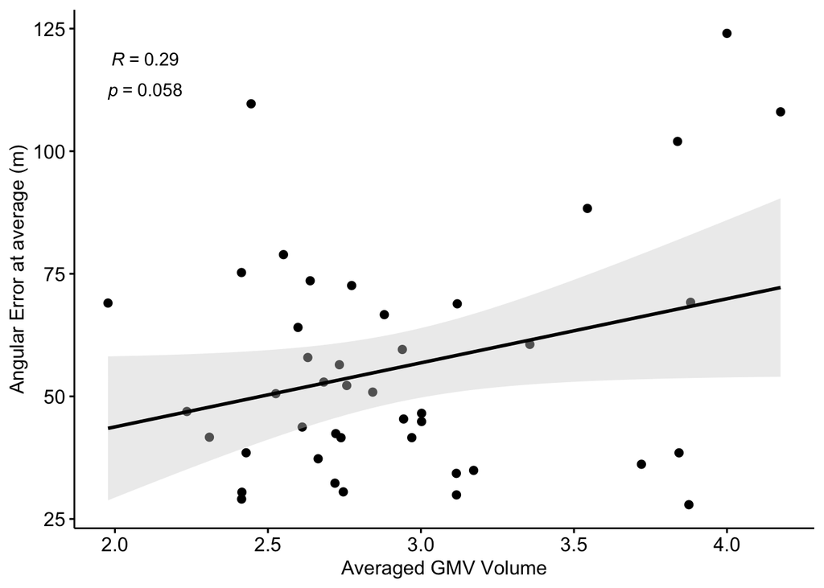

```r
# Use hp data frame adjusted
ggscatter(midlife_HP_df_adj, x = "avg_t1_hipp", y = "loop_ae_avg_degree",
          add = "reg.line",
          add.params = list(color = "black", fill = "lightgray"), # Customize reg. line
          cor.coef = TRUE, # Add correlation coefficient. see ?stat_cor
          conf.int = TRUE,
          cor.method = "pearson",
          cor.coeff.args = list(label.sep = "\n"),
          xlab = "Averaged GMV Volume", ylab = "Angular Error at average (m)", ) +
    theme(legend.position = "top", legend.title=element_blank())
```

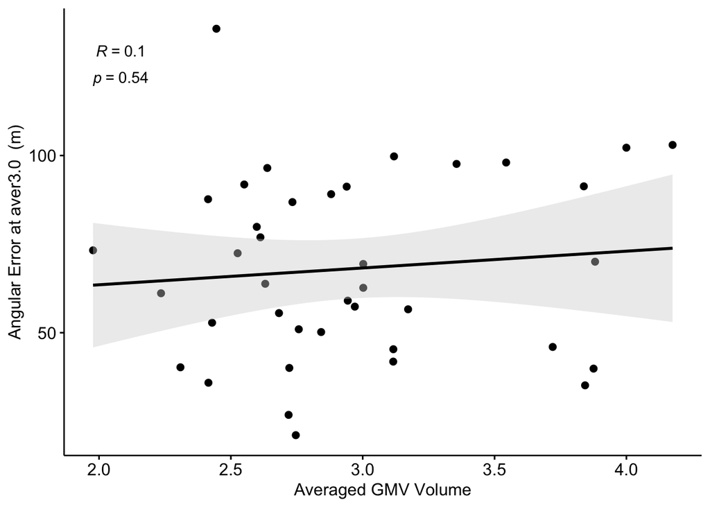

```r
# Use hp data frame adjusted
ggscatter(midlife_HP_df_adj, x = "avg_t1_hipp", y = "loop_ae_rad3_degree",
          add = "reg.line",
          add.params = list(color = "black", fill = "lightgray"), # Customize reg. line
          cor.coef = TRUE, # Add correlation coefficient. see ?stat_cor
          conf.int = TRUE,
          cor.method = "pearson",
          cor.coeff.args = list(label.sep = "\n"),
          xlab = "Averaged GMV Volume", ylab = "Angular Error at aver3.0  (m)", ) +
    theme(legend.position = "top", legend.title=element_blank())
```

** Degrees Traveled **

- Degrees Traveled is not significantly associated with t1 total hippocampus R=-0.17, p=0.28

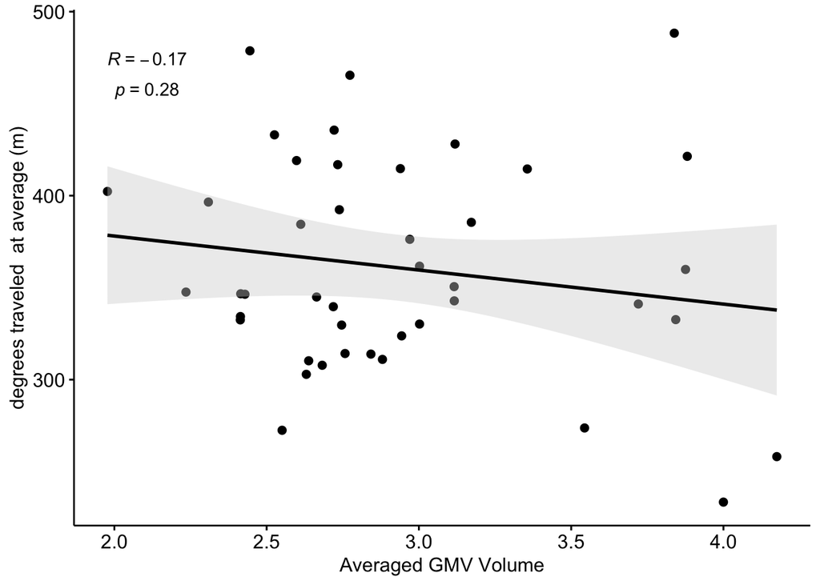

```r
# Use hp data frame adjusted
ggscatter(midlife_HP_df_adj, x = "avg_t1_hipp", y = "loop_de_avg_degree",
          add = "reg.line",
          add.params = list(color = "black", fill = "lightgray"), # Customize reg. line
          cor.coef = TRUE, # Add correlation coefficient. see ?stat_cor
          conf.int = TRUE,
          cor.method = "pearson",
          cor.coeff.args = list(label.sep = "\n"),
          xlab = "Averaged GMV Volume", ylab = "degrees traveled  at average (m)", ) +
    theme(legend.position = "top", legend.title=element_blank())
```

- degrees traveled is not significantly associated with t1 total hippocampus R=-0.079, p=0.63

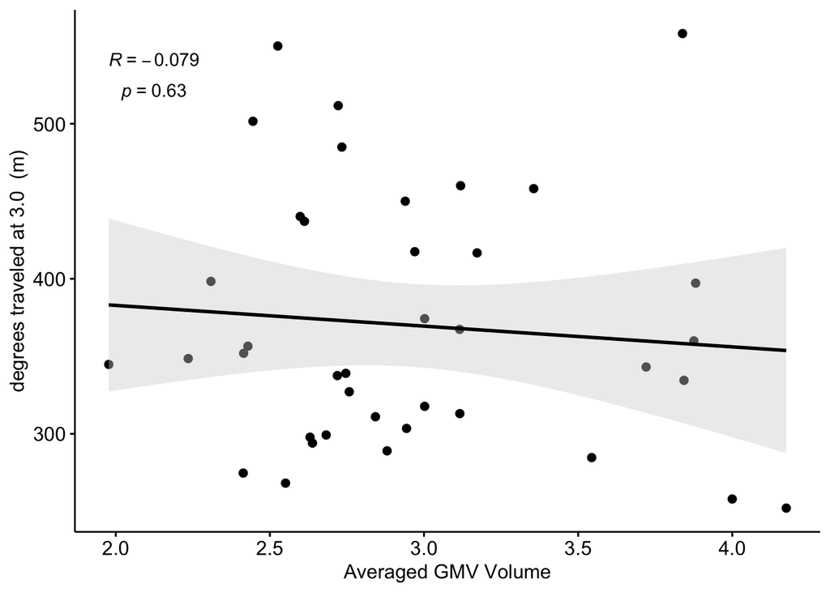

```r
# Use hp data frame adjusted
ggscatter(midlife_HP_df_adj, x = "avg_t1_hipp", y = "loop_de_rad3_degree",
          add = "reg.line",
          add.params = list(color = "black", fill = "lightgray"), # Customize reg. line
          cor.coef = TRUE, # Add correlation coefficient. see ?stat_cor
          conf.int = TRUE,
          cor.method = "spearman",
          cor.coeff.args = list(label.sep = "\n"),
          xlab = "Averaged GMV Volume", ylab = "degrees traveled at 3.0  (m)", ) +
    theme(legend.position = "top", legend.title=element_blank())
```

## Partial correlations using TIV as covariate

## Total hp

```r
# Use hp data frame adjusted
pcor.test(midlife_HP_df$loop_pe_avg_m, midlife_HP_df$avg_t1_hipp, midlife_HP_df$eTIV)
```

```
##      estimate   p.value  statistic  n gp  Method
## 1 -0.09949911 0.5307073 -0.6324259 43  1 pearson
```

```r
# Use hp data frame adjusted
midlife_hp_rad3 <- midlife_HP_df %>% filter(!is.na(loop_pe_rad3_m))
pcor.test(midlife_hp_rad3$loop_pe_rad3_m, midlife_hp_rad3$avg_t1_hipp, midlife_hp_rad3$eTIV)
```

```
##     estimate  p.value  statistic  n gp  Method
## 1 -0.1429717 0.391828 -0.8667343 39  1 pearson
```

** Angular Error **

```r
# Use hp data frame adjusted
pcor.test(midlife_HP_df$loop_ae_avg_degree, midlife_HP_df$avg_t1_hipp, midlife_HP_df$eTIV)
```

```
##     estimate   p.value  statistic  n gp  Method
## 1 -0.0569105 0.7203568 -0.3605179 43  1 pearson
```

```r
# Use hp data frame adjusted
midlife_hp_rad3 <- midlife_HP_df %>% filter(!is.na(loop_ae_rad3_degree))
pcor.test(midlife_hp_rad3$loop_ae_rad3_degree, midlife_hp_rad3$avg_t1_hipp, midlife_hp_rad3$eTIV)
```

```
##     estimate   p.value  statistic  n gp  Method
## 1 -0.1494153 0.3706105 -0.9066698 39  1 pearson
```

** Degrees Traveled **

```r
# Use hp data frame adjusted
pcor.test(midlife_HP_df$loop_de_avg_degree, midlife_HP_df$avg_t1_hipp, midlife_HP_df$eTIV)
```

```
##     estimate   p.value  statistic  n gp  Method
## 1 -0.1479331 0.3498185 -0.9460198 43  1 pearson
```

```r
# Use hp data frame adjusted
midlife_hp_rad3 <- midlife_HP_df %>% filter(!is.na(loop_de_rad3_degree))
pcor.test(midlife_hp_rad3$loop_de_rad3_degree, midlife_hp_rad3$avg_t1_hipp, midlife_hp_rad3$eTIV)
```

```
##     estimate   p.value  statistic  n gp  Method
## 1 -0.1583098 0.3424721 -0.9619898 39  1 pearson
```

# Young

Total N - 43

```r
# Let's create a clean df to work with here and include only the columns we want

young_HP_df <-
 young_raw_df %>%  dplyr::select(
    "subject_id",
    "sex",
    "age_spatial_years",
    "loop_pe_rad3_m",
    "loop_pe_avg_m",
    "loop_de_rad3_degree",
    "loop_de_avg_degree",
    "loop_ae_rad3_degree",
    "loop_ae_avg_degree",
    "Left-Hippocampus",
    "Right-Hippocampus",
    "eTIV"
  ) %>% mutate(avg_t1_hipp = (.$`Left-Hippocampus` + .$`Right-Hippocampus`) /
                 2) %>% filter(!is.na(eTIV)) # Need to make sure we remove subj without scan # N=43

young_HP_female_df <- young_HP_df %>% filter(sex=="Female")

young_HP_male_df <- young_HP_df %>%  filter(sex== "Male")
```

## Checking normality

```r
knitr::kable(normality_young_HP) %>% kable_styling(bootstrap_options =  c("striped", "hover", "condensed")) %>% scroll_box(width = "800px", height = "300px")
```

[output not shown]